# Weather Prediction (Time-series Analysis)

```python
from google.colab import drive
# import pandas as pd
# import numpy as np
import io
# import matplotlib.pyplot as plt
# import seaborn as sns


# Mount Google Drive
drive.mount('/content/drive')

file_path = '/content/drive/MyDrive/Colab Notebooks/Machine learning/CA2/PART B: SINGAPORE WEATHER DATA/Part B/Raw data'
```

```python
import pandas as pd
pd.set_option('future.no_silent_downcasting', True)
import numpy as np
import matplotlib.pyplot as plt
import itertools
```

```python
# You are provided with monthly data from January 1980 to January 2025.
# Define the year and month for the names of the csv files. The format is YYYYMM.
# One way is to use range(YYYY01, YYYY13) for all months of that year YYYY.
# The itertools.chain would concatenate all of them into one single list. Print out the list to view it.

ListOfMonths1 = list(itertools.chain(range(198001, 198013), range(198101, 198113), range(198201, 198213),
                                     range(198301, 198313), range(198401, 198413), range(198501, 198513),
                                     range(198601, 198613), range(198701, 198713), range(198801, 198813),
                                     range(198901, 198913), range(199001, 199013), range(199101, 199113),
                                     range(199201, 199213), range(199301, 199313), range(199401, 199413),
                                     range(199501, 199513), range(199601, 199613), range(199701, 199713),
                                     range(199801, 199813), range(199901, 199913), range(200001, 200013),
                                     range(200101, 200113), range(200201, 200213), range(200301, 200313),
                                     range(200401, 200413), range(200501, 200513), range(200601, 200613),
                                     range(200701, 200713), range(200801, 200813), range(200901, 200913),
                                     range(201001, 201013), range(201101, 201113), range(201201, 201213),
                                     range(201301, 201313), range(201401, 201413), range(201501, 201513),
                                     range(201601, 201613), range(201701, 201713), range(201801, 201813),
                                     range(201901, 201913), range(202001, 202013), range(202101, 202113),
                                     range(202201, 202213), range(202301, 202313), range(202401, 202413),
                                     range(202501, 202502)))
```

```python
# List comprehension to read each csv file with the given YYYYMM, and appending that dataframe into a list.
# So you have a list of all the data frames for each YYYYMM.
ListOfDF = [pd.read_csv(f'{file_path}/DAILYDATA_S24_{element}.csv') for element in ListOfMonths1]

# This will create a single dataframe, concatenating all of them.
df = pd.concat(ListOfDF)

# Replace '—' and '-' with NaN.
df.replace(['—', '-'], np.nan, inplace=True)

# Let us take a look at your combined (rather, concatenated) dataframe!
df
```

|  | Station | Year | Month | Day | Daily Rainfall Total (mm) | Highest 30 Min Rainfall (mm) | Highest 60 Min Rainfall (mm) | Highest 120 Min Rainfall (mm) | Mean Temperature (°C) | Maximum Temperature (°C) | Minimum Temperature (°C) | Mean Wind Speed (km/h) | Max Wind Speed (km/h) | \ | Highest 30 min Rainfall (mm) | Highest 60 min Rainfall (mm) | Highest 120 min Rainfall (mm) |
| --- | --- | --- | --- | --- | --- | --- | --- | --- | --- | --- | --- | --- | --- | --- | --- | --- | --- |
| 0 | Changi | 1980 | 1 | 1 | 0.0 | NaN | NaN | NaN | NaN | NaN | NaN | NaN | NaN | NaN | NaN | NaN | NaN |
| 1 | Changi | 1980 | 1 | 2 | 0.0 | NaN | NaN | NaN | NaN | NaN | NaN | NaN | NaN | NaN | NaN | NaN | NaN |
| 2 | Changi | 1980 | 1 | 3 | 0.0 | NaN | NaN | NaN | NaN | NaN | NaN | NaN | NaN | NaN | NaN | NaN | NaN |
| 3 | Changi | 1980 | 1 | 4 | 0.0 | NaN | NaN | NaN | NaN | NaN | NaN | NaN | NaN | NaN | NaN | NaN | NaN |
| 4 | Changi | 1980 | 1 | 5 | 8.0 | NaN | NaN | NaN | NaN | NaN | NaN | NaN | NaN | NaN | NaN | NaN | NaN |
| ... | ... | ... | ... | ... | ... | ... | ... | ... | ... | ... | ... | ... | ... | ... | ... | ... | ... |
| 26 | Changi | 2025 | 1 | 27 | 11.0 | NaN | NaN | NaN | 25.3 | 29.5 | 23.2 | 12.9 | 40.7 | NaN | 3.6 | 4.4 | 6.4 |
| 27 | Changi | 2025 | 1 | 28 | 0.0 | NaN | NaN | NaN | 26.6 | 29.6 | 25.3 | 20.7 | 51.9 | NaN | 0.0 | 0.0 | 0.0 |
| 28 | Changi | 2025 | 1 | 29 | 0.0 | NaN | NaN | NaN | 26.4 | 29.2 | 24.9 | 20.1 | 57.4 | NaN | 0.0 | 0.0 | 0.0 |
| 29 | Changi | 2025 | 1 | 30 | 0.0 | NaN | NaN | NaN | 26.6 | 30.3 | 24.1 | 17.1 | 51.9 | NaN | 0.0 | 0.0 | 0.0 |
| 30 | Changi | 2025 | 1 | 31 | 0.0 | NaN | NaN | NaN | 26.4 | 30.4 | 23.4 | 16.9 | 44.4 | NaN | 0.0 | 0.0 | 0.0 |

16468 rows × 17 columns

```python
# Let us create a datetime object using the year, month and day columns, and set that as the index of the dataframe.
df.set_index(pd.to_datetime(df[['Year', 'Month', 'Day']]), inplace=True)

# As a start, let us investigate these three quantities.
df = df[['Daily Rainfall Total (mm)', 'Mean Temperature (°C)', 'Mean Wind Speed (km/h)']]

# Set data types as float.
# Otherwise the "-" values replaced by "NaN" may make the data type as non-numeric and cannot be plotted.
df = df.astype(float)

# Let us print out our simpler and better organised dataframe!
df
```

|  | Daily Rainfall Total (mm) | Mean Temperature (°C) | Mean Wind Speed (km/h) |
| --- | --- | --- | --- |
| 1980-01-01 | 0.0 | NaN | NaN |
| 1980-01-02 | 0.0 | NaN | NaN |
| 1980-01-03 | 0.0 | NaN | NaN |
| 1980-01-04 | 0.0 | NaN | NaN |
| 1980-01-05 | 8.0 | NaN | NaN |
| ... | ... | ... | ... |
| 2025-01-27 | 11.0 | 25.3 | 12.9 |
| 2025-01-28 | 0.0 | 26.6 | 20.7 |
| 2025-01-29 | 0.0 | 26.4 | 20.1 |
| 2025-01-30 | 0.0 | 26.6 | 17.1 |
| 2025-01-31 | 0.0 | 26.4 | 16.9 |

16468 rows × 3 columns

```python
df.info()
```

```
<class 'pandas.core.frame.DataFrame'>
DatetimeIndex: 16468 entries, 1980-01-01 to 2025-01-31
Data columns (total 3 columns):
 #   Column                     Non-Null Count  Dtype
---  ------                     --------------  -----
 0   Daily Rainfall Total (mm)  16468 non-null  float64
 1   Mean Temperature (°C)      15737 non-null  float64
 2   Mean Wind Speed (km/h)     15360 non-null  float64
dtypes: float64(3)
memory usage: 514.6 KB
```

# EDA

The 3 plots are too noisy as too many spikes or data points to see. They are difficult for analysis.

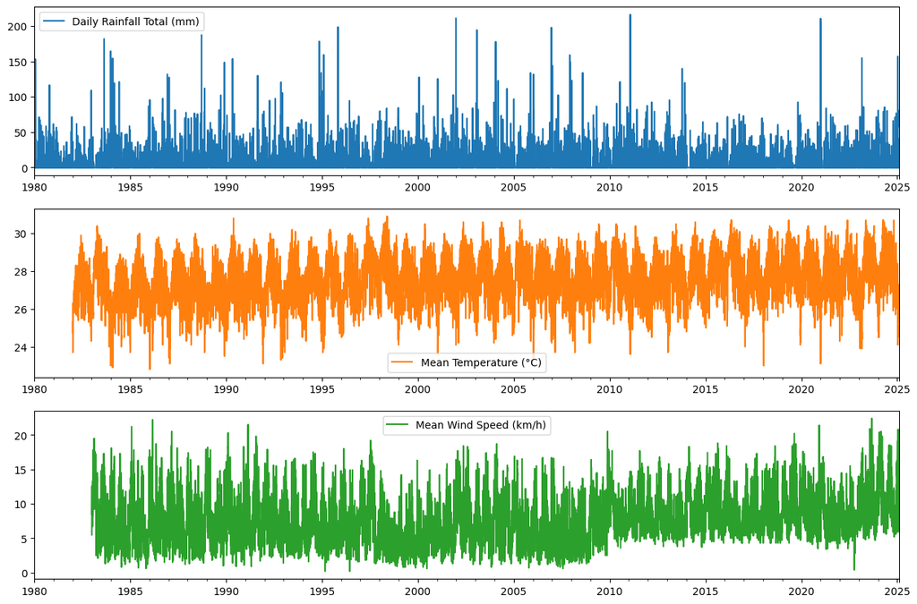

```python
# Some plots of the raw data.
import matplotlib.pyplot as plt

fig, ax = plt.subplots(3, 1, figsize=(15, 10))

df[['Daily Rainfall Total (mm)']].plot(ax=ax[0])
df[['Mean Temperature (°C)']].plot(ax=ax[1], c='C1')
df[['Mean Wind Speed (km/h)']].plot(ax=ax[2], c='C2')
plt.show()
```

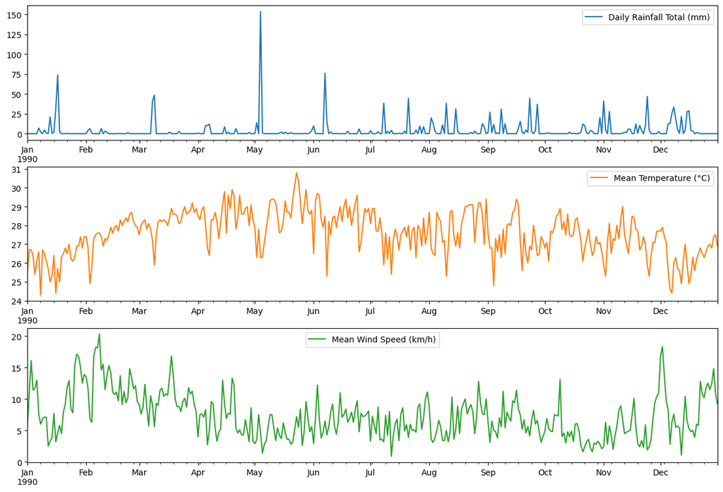

```python
# Just one year.

fig, ax = plt.subplots(3, 1, figsize=(15, 10))

df[['Daily Rainfall Total (mm)']]['1990':'1990'].plot(ax=ax[0])
df[['Mean Temperature (°C)']]['1990':'1990'].plot(ax=ax[1], c='C1')
df[['Mean Wind Speed (km/h)']]['1990':'1990'].plot(ax=ax[2], c='C2')
plt.show()
```

- We are able to do analysis in four-years plots because it can able to show the seasonal patterns
- El Nino typically brings warmer and drier conditions. This happens because the weakening of trade winds.

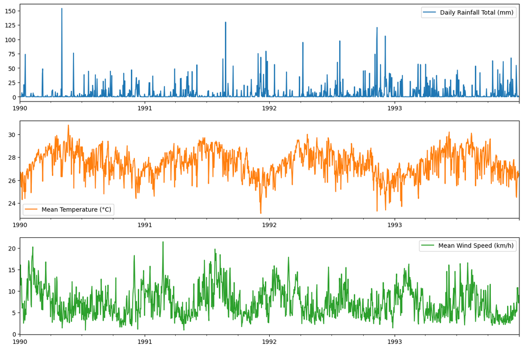

```python
# How about over four years?
# Maybe ENSO? La Nini, El Nino southern oscillation? How often do they recur?

fig, ax = plt.subplots(3, 1, figsize=(15, 10))

df[['Daily Rainfall Total (mm)']]['1990':'1993'].plot(ax=ax[0])
df[['Mean Temperature (°C)']]['1990':'1993'].plot(ax=ax[1], c='C1')
df[['Mean Wind Speed (km/h)']]['1990':'1993'].plot(ax=ax[2], c='C2')
plt.show()
```

- Check for any missing values

```python
# Check for any missing values that need to be handled before modeling.
print("Missing values before handling:")
print(df.isnull().sum())
```

```
Missing values before handling:
Daily Rainfall Total (mm)       0
Mean Temperature (°C)         731
Mean Wind Speed (km/h)       1108
dtype: int64
```

```python
print("Data Cleaning")
print("Missing values before cleaning:\n", df.isnull().sum())
df.fillna(method='ffill', inplace=True)

# Backward-fill the data. This handles any remaining NaNs at the start of the series.
df.fillna(method='bfill', inplace=True)

print("\nMissing values after cleaning:\n", df.isnull().sum())
```

```
Data Cleaning
Missing values before cleaning:
 Daily Rainfall Total (mm)       0
Mean Temperature (°C)         731
Mean Wind Speed (km/h)       1108
dtype: int64

Missing values after cleaning:
 Daily Rainfall Total (mm)    0
Mean Temperature (°C)        0
Mean Wind Speed (km/h)       0
dtype: int64
```

- The daily data of "Mean Temperature (°C)" is resampled to monthly averages to smooth out noise.
- We can have better observe long-term trends and seasonal patterns.
- From the plot we can see that the time series data is non-stationary.
- There is seasonal pattern and minor upward trend.

```
---< Data Preprocessing: Resampling to Monthly Averages >---
```

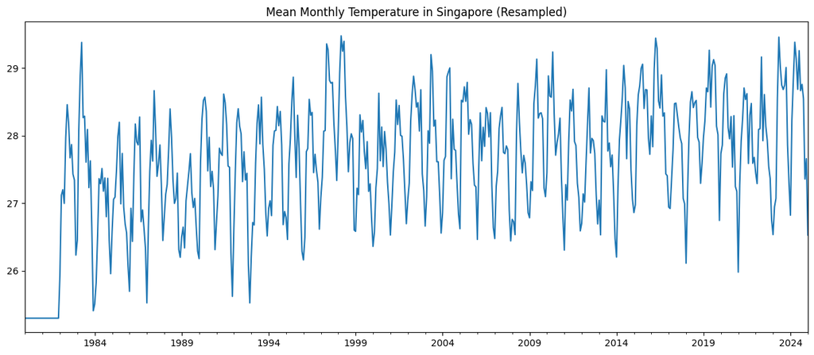

```python
# Resample the daily data to monthly
print("\n---< Data Preprocessing: Resampling to Monthly Averages >---")
df_monthly = df.resample('M').mean()
df_monthly['Mean Temperature (°C)'].plot(figsize=(15, 6))
plt.title('Mean Monthly Temperature in Singapore (Resampled)')
plt.show()
```

# 10 years training model

- Split the data from 1990-1999 to train the 10 years model.
- Split the data from 2000-2009 to test the 3 years prediction from 2000-2002.

```python
# Train-Test Split
train_10_years = df_monthly['1990':'1999']
test_10_years = df_monthly['2000':'2009']
```

```python
from statsmodels.tsa.stattools import adfuller

# Check for Stationarity
result = adfuller(train_10_years['Mean Temperature (°C)'])
print('ADF Test on Original 10-Year Data:')
print(f'ADF Statistic: {result[0]}')
print(f'p-value: {result[1]}')
```

```
ADF Test on Original 10-Year Data:
ADF Statistic: -1.6798983157128884
p-value: 0.4414980902572134
```

```python
# Re-run the ADF test to confirm stationarity.
train_10_years_diff = train_10_years['Mean Temperature (°C)'].diff().dropna()
result = adfuller(train_10_years_diff)
print('\nADF Test on Differenced 10-Year Data:')
print(f'ADF Statistic: {result[0]}')
print(f'p-value: {result[1]}')
```

```
ADF Test on Differenced 10-Year Data:
ADF Statistic: -4.5001669992850255
p-value: 0.00019650331816004998
```

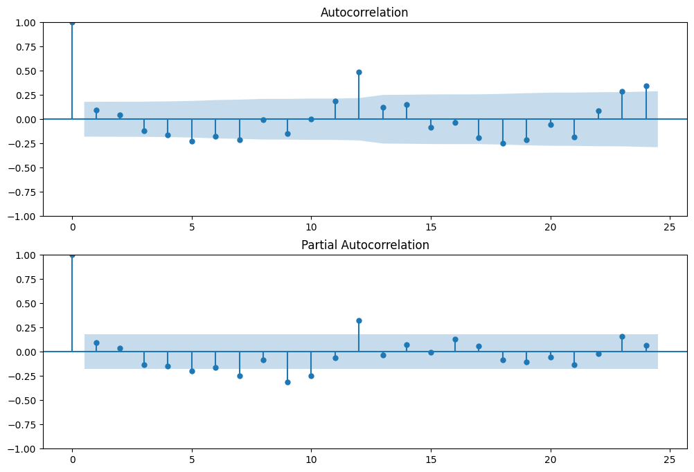

```
ACF shows a strong spike at lag 12, confirming yearly seasonality.
```

```python
# To identify the p and q orders from ACF and PACF plots
from statsmodels.graphics.tsaplots import plot_acf, plot_pacf

fig, (ax1, ax2) = plt.subplots(2,1, figsize=(12,8))
plot_acf(train_10_years_diff, lags=24, ax=ax1)
plot_pacf(train_10_years_diff, lags=24, ax=ax2)
plt.show()
print("ACF shows a strong spike at lag 12, confirming yearly seasonality.")
```

- Estimation:
- Use for loop with try except to manual search and store the values of different p, q, P, Q, AIC and BIC in the DataFrame.
- Sort the results to find the model with the lowest (best) AIC or BIC.
- AIC is better at choosing predictive models
- BIC is better at choosing good explanatory model
- Therefore, use the values of p, q, P, Q with lowest AIC value.

```python
# Estimation

from statsmodels.tsa.statespace.sarimax import SARIMAX

p_range = range(0, 3) # Non-seasonal AR order
d = 1                 # Non-seasonal differencing
q_range = range(0, 3) # Non-seasonal MA order

P_range = range(0, 3) # Seasonal AR order
D = 1                 # Seasonal differencing
Q_range = range(0, 3) # Seasonal MA order
m = 12                # Seasonal period (monthly data)

# Create a list to store the results
order_aic_bic = []

# Loop over all non-seasonal and seasonal order combinations
for p in p_range:
    for q in q_range:
        for P in P_range:
            for Q in Q_range:
                try:
                    order = (p, d, q)
                    seasonal_order = (P, D, Q, m)

                    # Fit the SARIMAX model
                    model = SARIMAX(train_10_years['Mean Temperature (°C)'],
                                    order=order,
                                    seasonal_order=seasonal_order)
                                    # enforce_stationarity=False,
                                    # enforce_invertibility=False)

                    results = model.fit()

                    # Add order and scores to the list
                    order_aic_bic.append((p, q, P, Q, results.aic, results.bic))
                    print(f"SARIMA({p},{d},{q})({P},{D},{Q})[{m}] - AIC:{results.aic:.2f}")

                except:
                    # If a model fails to fit, we print None for its scores
                    print(f"SARIMA({p},{d},{q})({P},{D},{Q})[{m}] - Failed to fit")
                    order_aic_bic.append((p, q, P, Q, None, None))
                    continue

# Make DataFrame of model order and AIC/BIC scores
order_df = pd.DataFrame(order_aic_bic, columns=['p', 'q', 'P', 'Q', 'aic', 'bic'])

# Sort by AIC to find the best model for prediction
print("Sorted by AIC:")
print(order_df.sort_values('aic'))
```

```
SARIMA(0,1,0)(0,1,0)[12] - AIC:186.84
SARIMA(0,1,0)(0,1,1)[12] - AIC:166.74
SARIMA(0,1,0)(0,1,2)[12] - AIC:167.23
SARIMA(0,1,0)(1,1,0)[12] - AIC:174.51
SARIMA(0,1,0)(1,1,1)[12] - AIC:166.71
SARIMA(0,1,0)(1,1,2)[12] - AIC:168.33
SARIMA(0,1,0)(2,1,0)[12] - AIC:172.79
SARIMA(0,1,0)(2,1,1)[12] - AIC:168.25
SARIMA(0,1,0)(2,1,2)[12] - AIC:169.84
SARIMA(0,1,1)(0,1,0)[12] - AIC:186.91
SARIMA(0,1,1)(0,1,1)[12] - AIC:160.02
SARIMA(0,1,1)(0,1,2)[12] - AIC:161.38
SARIMA(0,1,1)(1,1,0)[12] - AIC:169.65
SARIMA(0,1,1)(1,1,1)[12] - AIC:161.13
SARIMA(0,1,1)(1,1,2)[12] - AIC:162.55
SARIMA(0,1,1)(2,1,0)[12] - AIC:166.78
SARIMA(0,1,1)(2,1,1)[12] - AIC:162.31
```

```
SARIMA(0,1,1)(2,1,2)[12] - AIC:162.97
SARIMA(0,1,2)(0,1,0)[12] - AIC:179.64
SARIMA(0,1,2)(0,1,1)[12] - AIC:157.11
SARIMA(0,1,2)(0,1,2)[12] - AIC:158.37
SARIMA(0,1,2)(1,1,0)[12] - AIC:165.39
SARIMA(0,1,2)(1,1,1)[12] - AIC:158.11
SARIMA(0,1,2)(1,1,2)[12] - AIC:159.53
SARIMA(0,1,2)(2,1,0)[12] - AIC:163.11
SARIMA(0,1,2)(2,1,1)[12] - AIC:159.38
SARIMA(0,1,2)(2,1,2)[12] - AIC:160.18
SARIMA(1,1,0)(0,1,0)[12] - AIC:187.59
SARIMA(1,1,0)(0,1,1)[12] - AIC:162.53
SARIMA(1,1,0)(0,1,2)[12] - AIC:163.57
SARIMA(1,1,0)(1,1,0)[12] - AIC:172.20
SARIMA(1,1,0)(1,1,1)[12] - AIC:163.23
```

```
SARIMA(1,1,0)(1,1,2)[12] - AIC:164.77
SARIMA(1,1,0)(2,1,0)[12] - AIC:169.52
SARIMA(1,1,0)(2,1,1)[12] - AIC:164.63
SARIMA(1,1,0)(2,1,2)[12] - AIC:165.71
SARIMA(1,1,1)(0,1,0)[12] - AIC:174.95
SARIMA(1,1,1)(0,1,1)[12] - AIC:154.01
SARIMA(1,1,1)(0,1,2)[12] - AIC:154.58
SARIMA(1,1,1)(1,1,0)[12] - AIC:162.65
SARIMA(1,1,1)(1,1,1)[12] - AIC:154.33
SARIMA(1,1,1)(1,1,2)[12] - AIC:156.00
SARIMA(1,1,1)(2,1,0)[12] - AIC:159.55
SARIMA(1,1,1)(2,1,1)[12] - AIC:156.01
```

```
SARIMA(1,1,1)(2,1,2)[12] - AIC:157.41
SARIMA(1,1,2)(0,1,0)[12] - AIC:176.59
SARIMA(1,1,2)(0,1,1)[12] - AIC:155.42
SARIMA(1,1,2)(0,1,2)[12] - AIC:156.23
```

```
SARIMA(1,1,2)(1,1,0)[12] - AIC:164.43
SARIMA(1,1,2)(1,1,1)[12] - AIC:155.99
```

```
SARIMA(1,1,2)(1,1,2)[12] - AIC:157.61
SARIMA(1,1,2)(2,1,0)[12] - AIC:161.24
SARIMA(1,1,2)(2,1,1)[12] - AIC:157.61
SARIMA(1,1,2)(2,1,2)[12] - AIC:158.85
SARIMA(2,1,0)(0,1,0)[12] - AIC:186.60
SARIMA(2,1,0)(0,1,1)[12] - AIC:162.91
SARIMA(2,1,0)(0,1,2)[12] - AIC:164.27
SARIMA(2,1,0)(1,1,0)[12] - AIC:170.99
SARIMA(2,1,0)(1,1,1)[12] - AIC:163.98
SARIMA(2,1,0)(1,1,2)[12] - AIC:165.31
SARIMA(2,1,0)(2,1,0)[12] - AIC:169.08
SARIMA(2,1,0)(2,1,1)[12] - AIC:165.06
SARIMA(2,1,0)(2,1,2)[12] - AIC:165.98
SARIMA(2,1,1)(0,1,0)[12] - AIC:176.62
SARIMA(2,1,1)(0,1,1)[12] - AIC:155.39
SARIMA(2,1,1)(0,1,2)[12] - AIC:156.19
SARIMA(2,1,1)(1,1,0)[12] - AIC:164.45
SARIMA(2,1,1)(1,1,1)[12] - AIC:155.95
SARIMA(2,1,1)(1,1,2)[12] - AIC:157.58
SARIMA(2,1,1)(2,1,0)[12] - AIC:161.25
SARIMA(2,1,1)(2,1,1)[12] - AIC:157.57
SARIMA(2,1,1)(2,1,2)[12] - AIC:158.82
```

```
SARIMA(2,1,2)(0,1,0)[12] - AIC:177.95
```

```
SARIMA(2,1,2)(0,1,1)[12] - AIC:155.81
```

```
SARIMA(2,1,2)(0,1,2)[12] - AIC:156.17
```

```
SARIMA(2,1,2)(1,1,0)[12] - AIC:166.36
```

```
SARIMA(2,1,2)(1,1,1)[12] - AIC:155.98
```

```
SARIMA(2,1,2)(1,1,2)[12] - AIC:157.99
SARIMA(2,1,2)(2,1,0)[12] - AIC:162.66
```

```
SARIMA(2,1,2)(2,1,1)[12] - AIC:157.94
```

```
SARIMA(2,1,2)(2,1,2)[12] - AIC:159.33
Sorted by AIC:
    p  q  P  Q         aic         bic
37  1  1  0  1  154.006478  164.697793
40  1  1  1  1  154.330921  167.695065
38  1  1  0  2  154.576560  167.940705
64  2  1  0  1  155.394241  168.758385
46  1  2  0  1  155.424900  168.789044
.. .. .. .. ..         ...         ...
18  0  2  0  0  179.644431  187.662917
54  2  0  0  0  186.604797  194.623284
0   0  0  0  0  186.835055  189.507884
9   0  1  0  0  186.908529  192.254187
27  1  0  0  0  187.589121  192.934778

[81 rows x 6 columns]
```

- Model diagnostics:
- To check how good the final model is.
- If a model is good, its residuals should behave like white Gaussian noise
- Residuals plot: No obvious patterns or trends.
- Histogram plus estimated density: The histogram shows us the measured distribution. The model is good because the orange line and green line are almost the same.
- Normal Q-Q: To show how the distribution of the model residuals compares to a normal distribution. The residuals are normally distributed because almost all the points lie along the red line.
- Correlogram: It is just an ACF plot of the residuals. 95% of the correlations for lag greater than zero should not be significant. If there is significant correlation in the residuals, it means that there is information in the data that our model hasn't captured.
- Summary statistics:
- 1. Prob(Q): Tests if residuals are uncorrelated. P-value > 0.05 is good.
- 2. Prob(JB): Tests if residuals are normally distributed. P-value > 0.05 is good.

```
Plot diagnostic
```

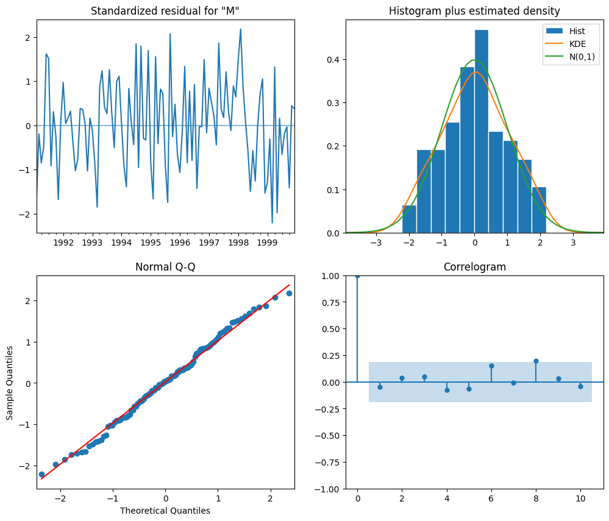

```
Diagnostic summary statistics
                                     SARIMAX Results
==========================================================================================
Dep. Variable:              Mean Temperature (°C)   No. Observations:                  120
Model:             SARIMAX(1, 1, 1)x(0, 1, 1, 12)   Log Likelihood                 -73.003
Date:                            Sun, 17 Aug 2025   AIC                            154.006
Time:                                    10:10:18   BIC                            164.698
Sample:                                01-31-1990   HQIC                           158.341
                                     - 12-31-1999
Covariance Type:                              opg
==============================================================================
                 coef    std err          z      P>|z|      [0.025      0.975]
------------------------------------------------------------------------------
ar.L1          0.6423      0.094      6.807      0.000       0.457       0.827
ma.L1         -0.9990      0.949     -1.052      0.293      -2.860       0.862
ma.S.L12      -0.6463      0.102     -6.366      0.000      -0.845      -0.447
sigma2         0.2065      0.195      1.058      0.290      -0.176       0.589
===================================================================================
Ljung-Box (L1) (Q):                   0.27   Jarque-Bera (JB):                 1.64
Prob(Q):                              0.60   Prob(JB):                         0.44
Heteroskedasticity (H):               1.40   Skew:                            -0.01
Prob(H) (two-sided):                  0.31   Kurtosis:                         2.39
===================================================================================

Warnings:
[1] Covariance matrix calculated using the outer product of gradients (complex-step).
```

```python
# Manual Model Diagnostics
best_model_manual = SARIMAX(train_10_years['Mean Temperature (°C)'],
                            order=(1, 1, 1),  # p(best), d, q(best)
                            seasonal_order=(0, 1, 1, 12)) # P(best), D, Q(best), m
best_results_manual = best_model_manual.fit(disp=False)

print("Plot diagnostic:")
best_results_manual.plot_diagnostics(figsize=(12, 10))
plt.show()

print("Diagnostic summary statistics:")
print(best_results_manual.summary())
```

- Search the best model order automatically with pm.auto_arima method.
- We can check the result of manual and auto search the best model order based on Prob(Q) and Prob(JB).
- 1. Prob(Q):
- Manual: 0.60
- Auto: 0.70
- 2. Prob(JB):
- Manual: 0.44
- Auto: 0.30
- Both manual and auto search results are more than 0.05

```python
# Automated model selection
import pmdarima as pm
auto_model_10 = pm.auto_arima(train_10_years['Mean Temperature (°C)'],
                             start_p=0, start_q=0,
                             max_p=2, max_q=2,
                             m=12, seasonal=True,
                             d=1, D=1)

print(auto_model_10.summary())
```

[output not shown]

```
                                      SARIMAX Results
============================================================================================
Dep. Variable:                                    y   No. Observations:                  120
Model:             SARIMAX(0, 1, 2)x(0, 1, [1], 12)   Log Likelihood                 -74.556
Date:                              Sun, 17 Aug 2025   AIC                            157.112
Time:                                      09:06:57   BIC                            167.803
Sample:                                  01-31-1990   HQIC                           161.446
                                       - 12-31-1999
Covariance Type:                                opg
==============================================================================
                 coef    std err          z      P>|z|      [0.025      0.975]
------------------------------------------------------------------------------
ma.L1         -0.3939      0.101     -3.894      0.000      -0.592      -0.196
ma.L2         -0.2348      0.090     -2.596      0.009      -0.412      -0.058
ma.S.L12      -0.6662      0.102     -6.536      0.000      -0.866      -0.466
sigma2         0.2200      0.037      5.888      0.000       0.147       0.293
===================================================================================
Ljung-Box (L1) (Q):                   0.14   Jarque-Bera (JB):                 2.39
Prob(Q):                              0.70   Prob(JB):                         0.30
Heteroskedasticity (H):               1.38   Skew:                            -0.17
Prob(H) (two-sided):                  0.34   Kurtosis:                         2.35
===================================================================================

Warnings:
[1] Covariance matrix calculated using the outer product of gradients (complex-step).
```

- Forecasting and evaluation section.
- Use the model that check with manual model diagnostics for prediction.
- Use one-step-ahead prediction to check how well the model would have predicted within the training dataset.

```
Mean Absolute Error (One-Step-Ahead, 3-Year Model): 0.34
```

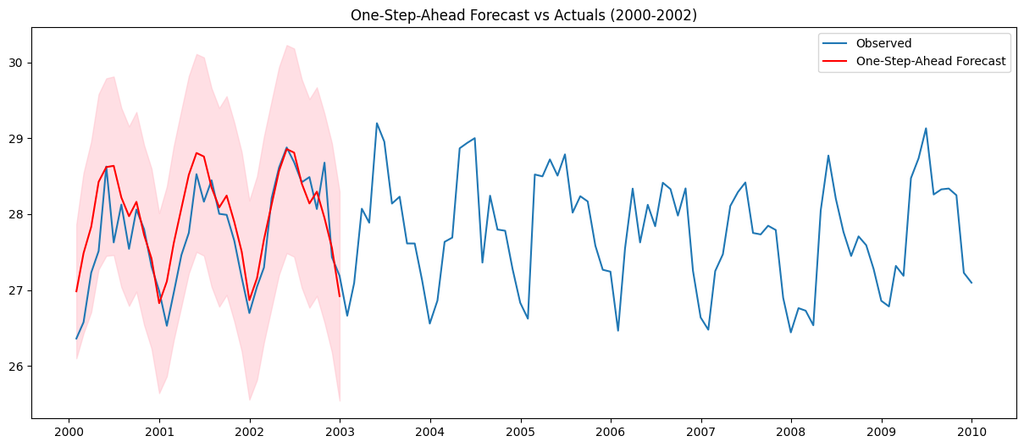

```python
# Forecasting and Evaluation
from statsmodels.tsa.statespace.sarimax import SARIMAX
from sklearn.metrics import mean_absolute_error

test_3_years = df_monthly['2000':'2002']
one_step_forecast_obj_3_years = best_results_manual.get_prediction(start='2000-01-31', end='2002-12-31')

# Confidence intervals
mean_forecast_3_step = one_step_forecast_obj_3_years.predicted_mean
conf_int_3_step = one_step_forecast_obj_3_years.conf_int()
lower_limits = conf_int_3_step.iloc[:, 0]
upper_limits = conf_int_3_step.iloc[:, 1]

# Calculate MAE
mae_one_step_3 = mean_absolute_error(test_3_years['Mean Temperature (°C)'], mean_forecast_3_step)  # test_3_years here is from 200001.csv to 200212.csv data
print(f"\nMean Absolute Error (One-Step-Ahead, 3-Year Model): {mae_one_step_3:.2f}")

plt.figure(figsize=(15, 6))
plt.plot(test_10_years.index, test_10_years['Mean Temperature (°C)'], label='Observed')
plt.plot(mean_forecast_3_step.index, mean_forecast_3_step, color='red', label='One-Step-Ahead Forecast')
plt.fill_between(mean_forecast_3_step.index, lower_limits, upper_limits, color='pink', alpha=0.5)
plt.title('One-Step-Ahead Forecast vs Actuals (2000-2002)')
plt.legend()
plt.show()
```

- The mean absolute error of predict for 3 years (0.34) is lower than predict for 10 year (0.48).
- This maybe because of the mean temperature of last 7 years have changed.

```
Mean Absolute Error (One-Step-Ahead, 10-Year Model): 0.48
```

[figure not shown]

```python
from sklearn.metrics import mean_absolute_error

# train on 1990-1999 and make one-step-ahead predictions on the 2000-2002 test set
one_step_forecast_obj = best_results_manual.get_prediction(start='2000-01-31', end='2009-12-31')

# Confidence intervals
mean_forecast_10_step = one_step_forecast_obj.predicted_mean
conf_int_10_step = one_step_forecast_obj.conf_int()
lower_limits = conf_int_10_step.iloc[:, 0]
upper_limits = conf_int_10_step.iloc[:, 1]

# Calculate MAE
mae_one_step_10 = mean_absolute_error(test_10_years['Mean Temperature (°C)'], mean_forecast_10_step)  # test_10_years here is from 200001.csv to 200912.csv data
print(f"\nMean Absolute Error (One-Step-Ahead, 10-Year Model): {mae_one_step_10:.2f}")

plt.figure(figsize=(15, 6))
plt.plot(test_10_years.index, test_10_years['Mean Temperature (°C)'], label='Observed')
plt.plot(mean_forecast_10_step.index, mean_forecast_10_step, color='red', label='One-Step-Ahead Forecast')
plt.fill_between(mean_forecast_10_step.index, lower_limits, upper_limits, color='pink', alpha=0.5)
plt.title('One-Step-Ahead Forecast vs Actuals (2000-2002)')
plt.legend()
plt.show()
```

20-YEAR TRAINING PERIOD (1990-2009)

```python
# Train-Test Split for 20 years training

train_20_years = df_monthly['1990':'2009']
test_20_years = df_monthly['2010':'2024']
```

```python
# Automated model selection
auto_model_20 = pm.auto_arima(train_20_years['Mean Temperature (°C)'],
                             start_p=0, start_q=0,
                             max_p=2, max_q=2,
                             m=12, seasonal=True,
                             d=1, D=1)

print("\nAuto-selected Model Summary (20-Year):")
print(auto_model_20.summary())
```

[output not shown]

```
Auto-selected Model Summary (20-Year):
                                      SARIMAX Results
===========================================================================================
Dep. Variable:                                   y   No. Observations:                  240
Model:             SARIMAX(1, 1, 1)x(2, 1, [], 12)   Log Likelihood                -149.183
Date:                             Sun, 17 Aug 2025   AIC                            308.366
Time:                                     09:07:53   BIC                            325.491
Sample:                                 01-31-1990   HQIC                           315.276
                                      - 12-31-2009
Covariance Type:                               opg
==============================================================================
                 coef    std err          z      P>|z|      [0.025      0.975]
------------------------------------------------------------------------------
ar.L1          0.3342      0.085      3.943      0.000       0.168       0.500
ma.L1         -0.8414      0.047    -17.913      0.000      -0.933      -0.749
ar.S.L12      -0.4774      0.068     -6.998      0.000      -0.611      -0.344
ar.S.L24      -0.2815      0.064     -4.412      0.000      -0.407      -0.156
sigma2         0.2136      0.022      9.608      0.000       0.170       0.257
===================================================================================
Ljung-Box (L1) (Q):                   0.15   Jarque-Bera (JB):                 1.01
Prob(Q):                              0.70   Prob(JB):                         0.60
Heteroskedasticity (H):               1.03   Skew:                            -0.09
Prob(H) (two-sided):                  0.88   Kurtosis:                         2.73
===================================================================================

Warnings:
[1] Covariance matrix calculated using the outer product of gradients (complex-step).
```

- All 4 plots below are showns that the model is good.

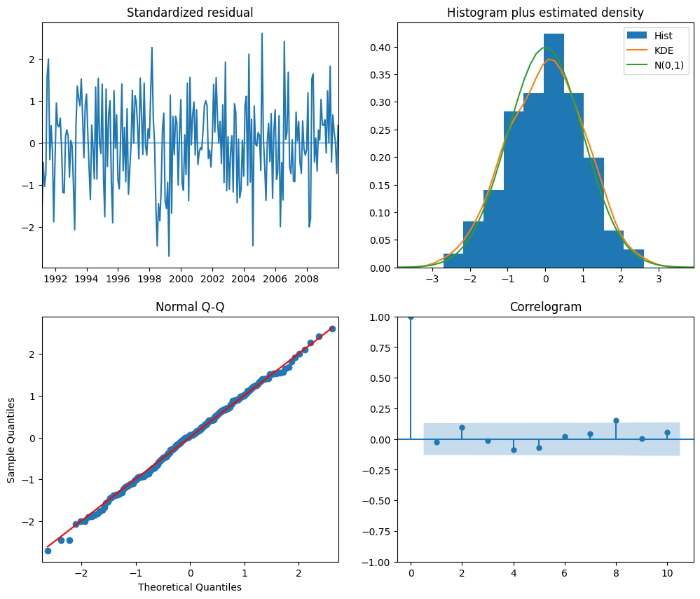

```python
# Diagnostics
auto_model_20.plot_diagnostics(figsize=(12, 10))
plt.show()
```

```python
best_model_manual = SARIMAX(train_20_years['Mean Temperature (°C)'],
                            order=(1, 1, 1),  # p(best), d, q(best)
                            seasonal_order=(2, 1, 0, 12)) # P(best), D, Q(best), m
best_results_manual = best_model_manual.fit(disp=False)
```

- The mean absolute error of 20 years training model (0.66) is higher than 10 years training model (0.34) for predict 3 years.
- This maybe because of the temperature patterns in in 2000-2009 period and the 2010-2024 period has been changed. Climate change can influence the temperature in ways that the model trained.

```
Mean Absolute Error (One-Step-Ahead, 20-Year Model): 0.66
```

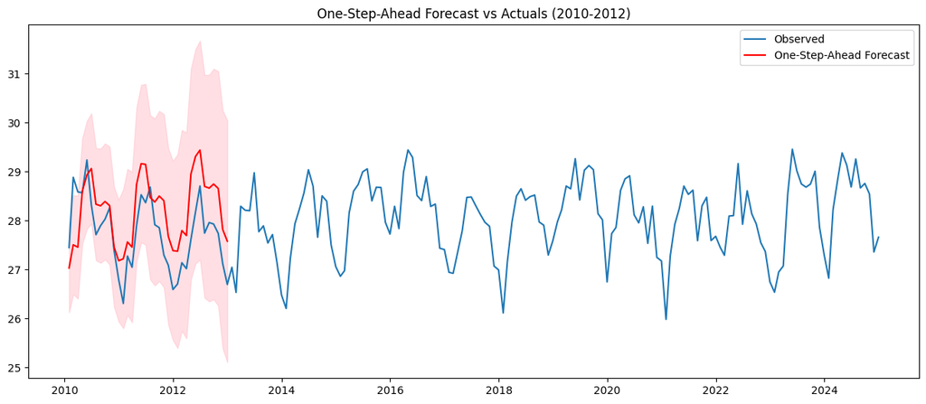

```python
# Forecasting and Evaluation
from sklearn.metrics import mean_absolute_error

test_3_years = df_monthly['2010':'2012']
one_step_forecast_obj_3_years = best_results_manual.get_prediction(start='2010-01-31', end='2012-12-31')

# Confidence intervals
mean_forecast_3_step = one_step_forecast_obj_3_years.predicted_mean
conf_int_3_step = one_step_forecast_obj_3_years.conf_int()
lower_limits = conf_int_3_step.iloc[:, 0]
upper_limits = conf_int_3_step.iloc[:, 1]

# Calculate MAE
mae_one_step_3 = mean_absolute_error(test_3_years['Mean Temperature (°C)'], mean_forecast_3_step)
print(f"\nMean Absolute Error (One-Step-Ahead, 20-Year Model): {mae_one_step_3:.2f}")

plt.figure(figsize=(15, 6))
plt.plot(test_20_years.index, test_20_years['Mean Temperature (°C)'], label='Observed')
plt.plot(mean_forecast_3_step.index, mean_forecast_3_step, color='red', label='One-Step-Ahead Forecast')
plt.fill_between(mean_forecast_3_step.index, lower_limits, upper_limits, color='pink', alpha=0.5)
plt.title('One-Step-Ahead Forecast vs Actuals (2010-2012)')
plt.legend()
plt.show()
```

```
Mean Absolute Error (One-Step-Ahead, 20-Year Model): 1.33
```

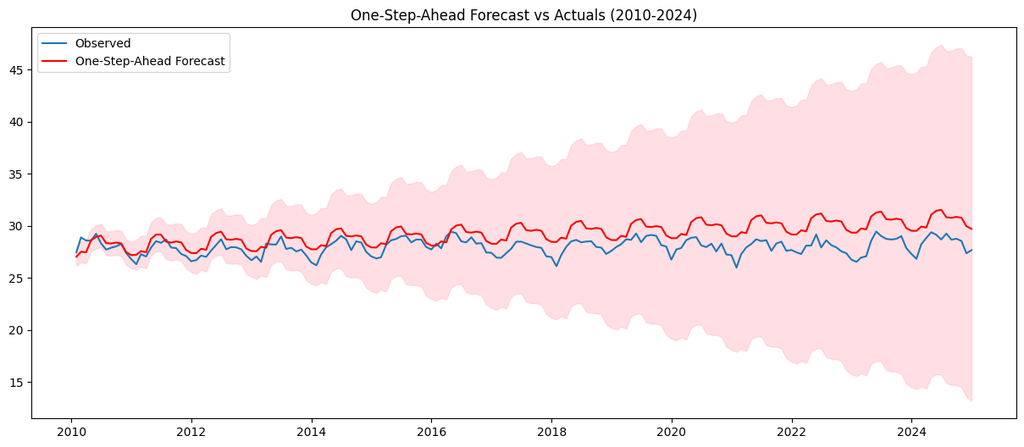

```python
# Forecasting and Evaluation
from sklearn.metrics import mean_absolute_error

test_10_years = df_monthly['2010':'2024']
one_step_forecast_obj_10_years = best_results_manual.get_prediction(start='2010-01-31', end='2024-12-31')

# Confidence intervals
mean_forecast_10_step = one_step_forecast_obj_10_years.predicted_mean
conf_int_10_step = one_step_forecast_obj_10_years.conf_int()
lower_limits = conf_int_10_step.iloc[:, 0]
upper_limits = conf_int_10_step.iloc[:, 1]

mae_one_step_3 = mean_absolute_error(test_10_years['Mean Temperature (°C)'], mean_forecast_10_step)
print(f"\nMean Absolute Error (One-Step-Ahead, 20-Year Model): {mae_one_step_3:.2f}")

plt.figure(figsize=(15, 6))
plt.plot(test_20_years.index, test_20_years['Mean Temperature (°C)'], label='Observed')
plt.plot(mean_forecast_10_step.index, mean_forecast_10_step, color='red', label='One-Step-Ahead Forecast')
plt.fill_between(mean_forecast_10_step.index, lower_limits, upper_limits, color='pink', alpha=0.5)
plt.title('One-Step-Ahead Forecast vs Actuals (2010-2024)')
plt.legend()
plt.show()
```

Question: Is the temperature consistently rising?

Question: Are we getting wetter days?

Question: Do we have more extreme weather events (anomaly detection)?

```
Plots below in monthly
```

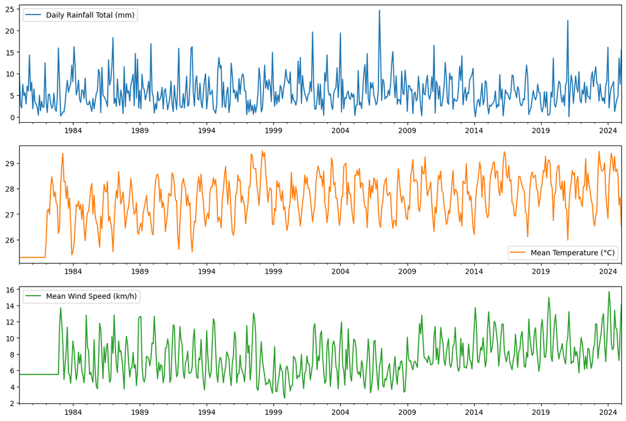

```python
import matplotlib.pyplot as plt

print("Plots below in monthly")

fig, ax = plt.subplots(3, 1, figsize=(15, 10))
df_monthly[['Daily Rainfall Total (mm)']].plot(ax=ax[0])
df_monthly[['Mean Temperature (°C)']].plot(ax=ax[1], c='C1')
df_monthly[['Mean Wind Speed (km/h)']].plot(ax=ax[2], c='C2')
plt.show()
```